# tech-report-2016

This page contains code associated with the following technical report:

Lee, Jackson L., Ross Burkholder, Gallagher B. Flinn, and Emily R. Coppess. 2016. [Working with CHAT transcripts in Python](http://www.cs.uchicago.edu/research/publications/techreports/TR-2016-02). Technical Report TR-2016-02, Department of Computer Science, University of Chicago.

Questions and comments can be directed to [Jackson Lee](http://jacksonllee.com/).

All code runs in Python 3.4+. Download this page as a `.py` Python script.

# Importing all necessary libraries

```python
%matplotlib inline

# libraries from the Python standard library
import os
from collections import Counter

# libraries for scientific computing and statistics
import pandas as pd
from scipy.stats.stats import pearsonr
import seaborn as sns
sns.set(color_codes=True)

# libraries for linguistic research
import pylangacq as pla
import pycantonese as pc
```

# Part 1: Computing MLUm

## Reading CHAT transcripts of Eve in Brown

We assume that Eve's data from the Brown portion of CHILDES ([source](http://childes.psy.cmu.edu/data/Eng-NA-MOR/Brown.zip); accessed in January 2016) are available at the current directory.

```python
eve = pla.read_chat('Brown/Eve/*.cha')  # reading in all 20 files from eve01.cha to eve20.cha
```

## Getting information of interest

1. filenames
2. age (in months) of Eve's in each CHAT file
3. mean length of utterance in morphemes (MLUm) of each file

```python
eve_filenames = eve.filenames(sorted_by_age=True)  # absolute-path filenames sorted by age
eve_ages = eve.age(month=True)  # dict(filename: age in months)
eve_MLUs = eve.MLUm()  # dict(filename: MLUm)
eve_age_MLU_pairs = [(eve_ages[fn], eve_MLUs[fn]) for fn in eve_filenames]  # list of (age, MLUm)
```

## Testing correlation (using Pearson's *r*)

```python
pearsonr(*zip(*eve_age_MLU_pairs))  # passing (list of ages, list of MLUs) to pearsonr()
```

```
(0.83768041227076273, 4.0563695482533856e-06)
```

**Between age and MLUm:** Significant (positive) correlation (r = 0.84, p < 0.001)

## Visualizing the correlation

```python
eve_MLU_df = pd.DataFrame({'Eve\'s age in months': [age for age, _ in eve_age_MLU_pairs],
                           'MLUm': [MLU for _, MLU in eve_age_MLU_pairs]})
```

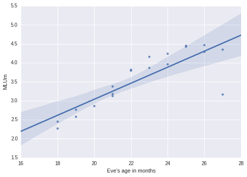

```python
eve_MLU_plot = sns.regplot(x='Eve\'s age in months', y='MLUm', data=eve_MLU_df)
```

```python
eve_MLU_plot.get_figure().savefig('Eve-MLU.pdf')  # save the figure for the tech report
```

## Printing LaTeX table code for the technical report

```python
for fn in sorted(eve_filenames):
    print('{{\\tt {}}} & {} & {:.3f} \\\\'.format(os.path.basename(fn), eve_ages[fn], eve_MLUs[fn]))
```

```
{\tt eve01.cha} & 18.0 & 2.267 \\
{\tt eve02.cha} & 18.0 & 2.449 \\
{\tt eve03.cha} & 19.0 & 2.763 \\
{\tt eve04.cha} & 19.0 & 2.576 \\
{\tt eve05.cha} & 20.0 & 2.859 \\
{\tt eve06.cha} & 21.0 & 3.177 \\
{\tt eve07.cha} & 21.0 & 3.123 \\
{\tt eve08.cha} & 21.0 & 3.374 \\
{\tt eve09.cha} & 22.0 & 3.818 \\
{\tt eve10.cha} & 22.0 & 3.792 \\
{\tt eve11.cha} & 23.0 & 3.866 \\
{\tt eve12.cha} & 23.0 & 4.157 \\
{\tt eve13.cha} & 24.0 & 4.239 \\
{\tt eve14.cha} & 24.0 & 3.960 \\
{\tt eve15.cha} & 25.0 & 4.450 \\
{\tt eve16.cha} & 25.0 & 4.424 \\
{\tt eve17.cha} & 26.0 & 4.466 \\
{\tt eve18.cha} & 26.0 & 4.288 \\
{\tt eve19.cha} & 27.0 & 4.348 \\
{\tt eve20.cha} & 27.0 & 3.163 \\
```

# Part 2: Language dominance

## Reading CHAT transcripts from YipMatthews

We assume that the YipMatthews datasets from the Biling portion of CHILDES ([source](http://childes.psy.cmu.edu/data/Biling/YipMatthews.zip); accessed in January 2016) are available at the current directory.

We are using the data from the three siblings of Timmy (eldest), Sophie, and Alicia (youngest) acquiring Cantonese and English simultaneously.

```python
tim_can = pla.read_chat('YipMatthews/CanWork/TimCan/*.cha')
sophie_can = pla.read_chat('YipMatthews/CanWork/SophieCan/*.cha')
alicia_can = pla.read_chat('YipMatthews/Can/AliciaCan/*.cha')

tim_eng = pla.read_chat('YipMatthews/Eng/TimEng/*.cha')
sophie_eng = pla.read_chat('YipMatthews/Eng/SophieEng/*.cha')
alicia_eng = pla.read_chat('YipMatthews/Eng/AliciaEng/*.cha')
```

## Visualizing language dominance by MLUw

We explore Cantonese-English language dominance (measured by MLUw) of the three siblings.

```python
def visualize_can_eng_MLUw(child_name, can_reader, eng_reader, legend=True):
    x_label = '{}\'s age in months'.format(child_name)

    can_filenames = can_reader.filenames(sorted_by_age=True)
    can_ages = can_reader.age(month=True)
    can_MLUs = can_reader.MLUw()

    eng_filenames = eng_reader.filenames(sorted_by_age=True)
    eng_ages = eng_reader.age(month=True)
    eng_MLUs = eng_reader.MLUw()

    df = pd.DataFrame({x_label: [can_ages[fn] for fn in can_filenames] + [eng_ages[fn] for fn in eng_filenames],
                       'MLUw': [can_MLUs[fn] for fn in can_filenames] + [eng_MLUs[fn] for fn in eng_filenames],
                       'Language': ['Cantonese']*len(can_reader) + ['English']*len(eng_reader)})

    MLU_plot = sns.lmplot(x=x_label, y='MLUw', hue='Language', data=df, markers=['o', 'x'],
                          legend=legend, legend_out=False)
    MLU_plot.set(xlim=(10, 45), ylim=(0, 4.5))
    MLU_plot.savefig('{}-MLU.pdf'.format(child_name))
```

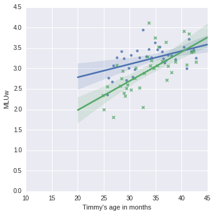

```python
visualize_can_eng_MLUw('Timmy', tim_can, tim_eng, legend=False)  # figure saved: Timmy-MLU.pdf
```

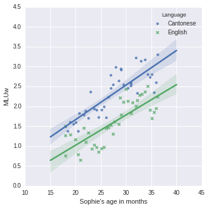

```python
visualize_can_eng_MLUw('Sophie', sophie_can, sophie_eng)  # figure saved: Sophie-MLU.pdf
```

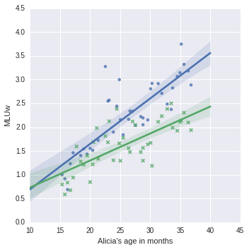

```python
visualize_can_eng_MLUw('Alicia', alicia_can, alicia_eng, legend=False)  # figure saved: Alicia-MLU.pdf
```

# Part 3: Phonological development

## Reading CHAT transcripts from LeeWongLeung

We assume that the LeeWongLeung datasets from the EastAsian/Cantonese portion of CHILDES ([source](http://childes.psy.cmu.edu/data/EastAsian/Cantonese/LeeWongLeung.zip); accessed in January 2016) are available at the current directory.

We are using the data for the child "mhz".

```python
mhz = pla.read_chat('LeeWongLeung/mhz/*.cha')
```

## Getting information of interest

1. filenames
2. ages (in months)
3. list of tagged words for each file; a tagged word is a tuple of (word, pos, mor, rel)

```python
mhz_filenames = mhz.filenames(sorted_by_age=True)  # list of absolute-path filenames sorted by age
mhz_ages = mhz.age(month=True)  # dict(filename: age in months)
mhz_ages_sorted = [mhz_ages[fn] for fn in mhz_filenames]  # list of ages sorted by mhz_filenames
mhz_tagged_words = mhz.tagged_words(by_files=True, participant='CHI')  # dict(filename: list of tagged words)
```

## Counting tones in each file

Cantonese has six tones. Cantonese datasets in CHILDES simply have them transcribed as {1, 2, 3, 4, 5, 6}, following the convention in Cantonese linguistics.

```python
age_to_tones = dict()  # dict(age: dict(tone: tone count))

for fn in mhz_filenames:
    tagged_words = mhz_tagged_words[fn]
    age = mhz_ages[fn]

    age_to_tones[age] = Counter()

    for tagged_word in tagged_words:

        # jyutping should be like "gaa1jau2" (two syllables), "ngo5" (one syllable) etc
        mor = tagged_word[2]
        jyutping, _, _ = mor.partition('-')
        jyutping, _, _ = jyutping.partition('&')

        if not jyutping:
            continue

        # use PyCantonese to parse the "jyutping" str
        try:
            jyutping_parsed_list = pc.parse_jyutping(jyutping)
        except:
            continue

        for jyutping_parsed in jyutping_parsed_list:
            _, _, _, tone = jyutping_parsed  # (onset, nucleus, coda, tone)
            age_to_tones[age][tone] += 1
```

## Creating the dataframe for plotting the desired heatmap

The dataframe has three columns and is created by `data_dict`.

```python
data_dict = {'MHZ\'s age in months': list(),
             'Tone': list(),
             'Count': list(),
            }

for age in age_to_tones:
    for tone in age_to_tones[age]:
        count_ = age_to_tones[age][tone]
        data_dict['MHZ\'s age in months'].append(round(age, 1))
        data_dict['Tone'].append(int(tone))
        data_dict['Count'].append(count_)

df = pd.DataFrame(data_dict)
df_pivot = df.pivot('Tone', 'MHZ\'s age in months', 'Count')
```

## Plotting the heatmap

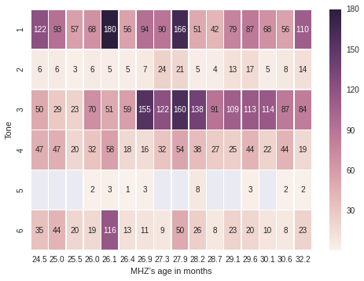

```python
mhz_heatmap = sns.heatmap(df_pivot, annot=True, fmt='.3g', linewidths=0.1)
mhz_heatmap.get_figure().savefig('MHZ-Tone.pdf')
```